# Experiment - Gender Prediction

- StellarAlgo Data Science
- March 24, 2023
- Grant Donst, Peter Morrison

```python
import pandas as pd
import os

from data_sci_toolkit.aws_tools import redshift_tools
from pycaret.classification import *

import gender_guesser.detector as gender
```

# Load in Data

Running query to gather first name, gender, and other possible features from cohortcustomer, cohortmerch, and cohortconcession

```python
query = """
select cc.gender, cc.dimcustomermasterid, cc.lkupclientid, cc.namefirst, cc.income, cc.education, cc.occupation, cc.monetary_tier_overall, cc.engagementbucket, cc.loyaltypointbalance, cc.isgamer, cm.itemdescription, cm.itemcount, cm.itemrevenue, ccon.purchasecount, ccon.totalspent
from dw.cohortcustomer cc
	left join dw.cohortmerch cm on cc.dimcustomermasterid = cm.dimcustomermasterid
	left join dw.cohortconcession ccon on cc.dimcustomermasterid = ccon.dimcustomermasterid
where cc.gender is not null
and cc.namefirst is not null;
"""

cluster = "prod-app"
database = "stlrnfl49ers"
```

```python
conn = redshift_tools.get_redshift_connection(cluster, database)

cur = conn.cursor()
cur.execute(query)

data = cur.fetchall()

cols = [row[0] for row in cur.description]
df = pd.DataFrame(data=data, columns=cols)

conn.close()
```

```
Authorized as AROASQ4JELIXYLYV6P4UV:pmorrison@stellaralgo.com
```

```python
df_temp = df
```

```python
df_temp.shape
```

```
(8901560, 16)
```

# Pre-Processing

We will preprocess the data, so we can have a predicted score of their gender and clean other data.

```python
df_temp["namefirst"] = df_temp["namefirst"].apply(lambda x: x.title())
```

```python
gdectect = gender.Detector()
```

```python
df_temp["name_gender_predict"] = df_temp["namefirst"].apply(gdectect.get_gender)
```

The unknowns below are things like "John2" or "Jhon", aka, misspelled names. Therefore, we are going to drop all unknowns.

```python
df_temp.name_gender_predict.value_counts()
```

```
male             4560797
female           2601107
unknown           950780
mostly_male       394851
mostly_female     312803
andy               81222
Name: name_gender_predict, dtype: int64
```

```python
df_temp = df_temp.drop(df_temp[df_temp["name_gender_predict"]=="unknown"].index)
df_temp.reset_index()
```

```python
df_temp.name_gender_predict.value_counts()
```

```
male             4560797
female           2601107
mostly_male       394851
mostly_female     312803
andy               81222
Name: name_gender_predict, dtype: int64
```

```python
df_temp["totalspent"] = df_temp["totalspent"].fillna(0)
df_temp["income"] = df_temp["income"].fillna(0)
```

```python
df_temp["itemcount"] = df_temp["itemcount"].fillna(0)
```

```python
df_temp["gender"] = df_temp["gender"].apply(lambda x: x.lower())
```

```python
df_temp["gender"].value_counts()
```

```
male      4724844
female    2666766
u          559170
Name: gender, dtype: int64
```

# Train Model

```python
setup(
    data=df_temp,
    target='gender',
    train_size=0.85,
    data_split_shuffle=True,
    silent=True,
    verbose=False,
    ignore_features=["dimcustomermasterid", "lkupclientid", "namefirst", "itemdescription"],
    numeric_features=["totalspent", "income"]
)
```

[output not shown]

[output cut: 982 more lines]

[output not shown]

```python
model_matrix = compare_models(
    fold=2,
    include= ["catboost"]
)
```

|  | Model | Accuracy | AUC | Recall | Prec. | F1 | Kappa | MCC | TT (Sec) |
| --- | --- | --- | --- | --- | --- | --- | --- | --- | --- |
| catboost | CatBoost Classifier | 0.9021 | 0.9352 | 0.6497 | 0.8738 | 0.8710 | 0.8047 | 0.8121 | 135.3550 |

```python
best_model = create_model(model_matrix, fold=2);
```

| Fold | Accuracy | AUC | Recall | Prec. | F1 | Kappa | MCC |
| --- | --- | --- | --- | --- | --- | --- | --- |
| 0 | 0.9020 | 0.9352 | 0.6497 | 0.8740 | 0.8710 | 0.8046 | 0.8120 |
| 1 | 0.9021 | 0.9353 | 0.6497 | 0.8735 | 0.8710 | 0.8048 | 0.8122 |
| Mean | 0.9021 | 0.9352 | 0.6497 | 0.8738 | 0.8710 | 0.8047 | 0.8121 |
| Std | 0.0000 | 0.0001 | 0.0000 | 0.0002 | 0.0000 | 0.0001 | 0.0001 |

```python
# best_model = tune_model(best_model)
```

```python
# final_model = finalize_model(best_model)
```

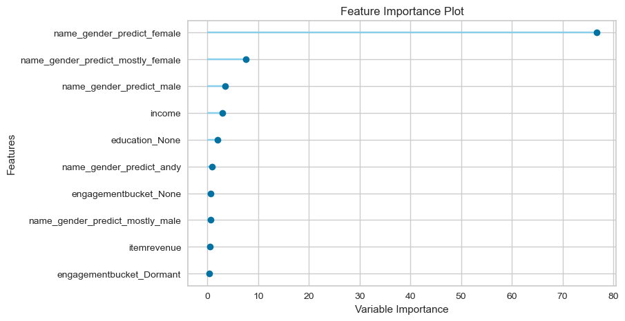

```python
plot_model(best_model, plot="feature")
```

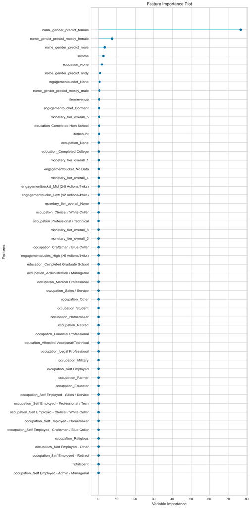

```python
plot_model(best_model, plot="feature_all")
```

```python
predict_model(best_model)
```

|  | Model | Accuracy | AUC | Recall | Prec. | F1 | Kappa | MCC |
| --- | --- | --- | --- | --- | --- | --- | --- | --- |
| 0 | CatBoost Classifier | 0.9021 | 0.9352 | 0.6495 | 0.8741 | 0.8711 | 0.8046 | 0.8119 |

|  | income | itemcount | itemrevenue | totalspent | education_Attended Vocational/Technical | education_Completed College | education_Completed Graduate School | education_Completed High School | education_None | occupation_Administration / Managerial | ... | engagementbucket_No Data | engagementbucket_None | name_gender_predict_andy | name_gender_predict_female | name_gender_predict_male | name_gender_predict_mostly_female | name_gender_predict_mostly_male | gender | Label | Score |
| --- | --- | --- | --- | --- | --- | --- | --- | --- | --- | --- | --- | --- | --- | --- | --- | --- | --- | --- | --- | --- | --- |
| 0 | 0.0 | 0.0 | 58.553612 | 0.0 | 0.0 | 0.0 | 0.0 | 0.0 | 1.0 | 0.0 | ... | 0.0 | 1.0 | 0.0 | 0.0 | 1.0 | 0.0 | 0.0 | male | male | 0.9465 |
| 1 | 0.0 | 0.0 | 58.553612 | 0.0 | 0.0 | 0.0 | 0.0 | 0.0 | 1.0 | 0.0 | ... | 1.0 | 0.0 | 1.0 | 0.0 | 0.0 | 0.0 | 0.0 | u | male | 0.4271 |
| 2 | 0.0 | 0.0 | 58.553612 | 0.0 | 0.0 | 0.0 | 0.0 | 0.0 | 1.0 | 0.0 | ... | 0.0 | 1.0 | 0.0 | 0.0 | 0.0 | 0.0 | 1.0 | male | male | 0.8294 |
| 3 | 0.0 | 0.0 | 58.553612 | 0.0 | 0.0 | 0.0 | 0.0 | 0.0 | 1.0 | 0.0 | ... | 0.0 | 1.0 | 0.0 | 0.0 | 1.0 | 0.0 | 0.0 | male | male | 0.9465 |
| 4 | 0.0 | 0.0 | 58.553612 | 0.0 | 0.0 | 0.0 | 0.0 | 0.0 | 1.0 | 0.0 | ... | 0.0 | 1.0 | 0.0 | 0.0 | 1.0 | 0.0 | 0.0 | male | male | 0.9465 |
| ... | ... | ... | ... | ... | ... | ... | ... | ... | ... | ... | ... | ... | ... | ... | ... | ... | ... | ... | ... | ... | ... |
| 1192613 | 0.0 | 0.0 | 58.553612 | 0.0 | 0.0 | 0.0 | 0.0 | 0.0 | 1.0 | 0.0 | ... | 0.0 | 1.0 | 0.0 | 1.0 | 0.0 | 0.0 | 0.0 | female | female | 0.9268 |
| 1192614 | 0.0 | 0.0 | 58.553612 | 0.0 | 0.0 | 0.0 | 0.0 | 0.0 | 1.0 | 0.0 | ... | 0.0 | 1.0 | 0.0 | 0.0 | 1.0 | 0.0 | 0.0 | male | male | 0.9465 |
| 1192615 | 0.0 | 0.0 | 58.553612 | 0.0 | 0.0 | 0.0 | 0.0 | 0.0 | 1.0 | 0.0 | ... | 0.0 | 1.0 | 0.0 | 0.0 | 1.0 | 0.0 | 0.0 | male | male | 0.9465 |
| 1192616 | 0.0 | 0.0 | 58.553612 | 0.0 | 0.0 | 0.0 | 0.0 | 0.0 | 1.0 | 0.0 | ... | 0.0 | 1.0 | 0.0 | 1.0 | 0.0 | 0.0 | 0.0 | u | female | 0.9268 |
| 1192617 | 0.0 | 0.0 | 58.553612 | 0.0 | 0.0 | 0.0 | 0.0 | 0.0 | 1.0 | 0.0 | ... | 0.0 | 1.0 | 0.0 | 0.0 | 1.0 | 0.0 | 0.0 | male | male | 0.9465 |

1192618 rows × 55 columns

# Inference Tests

```python
query = """
select cc.gender, cc.dimcustomermasterid, cc.lkupclientid, cc.namefirst, cc.income, cc.education, cc.occupation, cc.monetary_tier_overall, cc.engagementbucket, cc.loyaltypointbalance, cc.isgamer, cm.itemdescription, cm.itemcount, cm.itemrevenue, ccon.purchasecount, ccon.totalspent
from dw.cohortcustomer cc
	left join dw.cohortmerch cm on cc.dimcustomermasterid = cm.dimcustomermasterid
	left join dw.cohortconcession ccon on cc.dimcustomermasterid = ccon.dimcustomermasterid
where cc.gender is null;
"""

cluster = "prod-app"
database = "stlrtrailblazers"
```

```python
conn = redshift_tools.get_redshift_connection(cluster, database)

cur = conn.cursor()
cur.execute(query)

data = cur.fetchall()

cols = [row[0] for row in cur.description]
df = pd.DataFrame(data=data, columns=cols)

conn.close()
```

```
Authorized as AROASQ4JELIXYLYV6P4UV:pmorrison@stellaralgo.com
```

```python
inference_name = df
```

```python
inference_name.shape
```

```
(1356061, 16)
```

### Pre-Processing

We will preprocess the data, so we can have a predicted score of their gender and clean other data.

```python
gdectect = gender.Detector()
```

```python
inference_name["name_gender_predict"] = inference_name["namefirst"].apply(gdectect.get_gender)
```

```python
inference_name.name_gender_predict.value_counts()
```

```
male             537956
female           419245
unknown          256731
mostly_male       66460
mostly_female     57582
andy              18087
Name: name_gender_predict, dtype: int64
```

```python
inference_name["totalspent"] = inference_name["totalspent"].fillna(0)
```

```python
inference_name["itemcount"] = inference_name["itemcount"].fillna(0)
```

```python
inference_name = inference_name.drop(columns=["gender"], axis=1)
```

```python
name_results = predict_model(best_model, inference_name)
```

```python
name_results.groupby(["name_gender_predict", "Label"]).agg({"Score":"mean"})
```

| name_gender_predict | Label | Score |
| --- | --- | --- |
| andy | female | 0.458492 |
|  | male | 0.444960 |
|  | u | 0.444000 |
| female | female | 0.942483 |
| male | male | 0.939157 |
| mostly_female | female | 0.668989 |
|  | male | 0.486750 |
| mostly_male | male | 0.844251 |
| unknown | female | 0.463717 |
|  | male | 0.444924 |
|  | u | 0.443736 |

# Train with Smote

```python
# setup(
#     data=df_temp,
#     target='gender',
#     train_size=0.85,
#     data_split_shuffle=True,
#     silent=True,
#     verbose=False,
#     fix_imbalance=True,
#     ignore_features=["dimcustomermasterid", "lkupclientid", "namefirst", "itemdescription"],
#     numeric_features=["totalspent"]
# )
```

```python
# smote_model_matrix = compare_models(
#     fold=2,
#     include= ["lightgbm", "catboost", "rf", "svm", "xgboost"]
# )
```

# Train without Name Data

We wanted to determine if name_gender_predict is the most important factor in predicting a persons gender.

```python
setup(
    data=df_temp,
    target='gender',
    train_size=0.85,
    data_split_shuffle=True,
    silent=True,
    verbose=False,
    ignore_features=["dimcustomermasterid", "lkupclientid", "namefirst", "itemdescription", "name_gender_predict"],
    numeric_features=["totalspent"]
)
```

[output not shown]

[output cut: 852 more lines]

[output not shown]

```python
smote_model_matrix = compare_models(
    fold=2,
    include= ["lightgbm", "catboost", "rf", "svm", "xgboost", "dummy"]
)
```

|  | Model | Accuracy | AUC | Recall | Prec. | F1 | Kappa | MCC | TT (Sec) |
| --- | --- | --- | --- | --- | --- | --- | --- | --- | --- |
| catboost | CatBoost Classifier | 0.6029 | 0.5665 | 0.3583 | 0.5754 | 0.5128 | 0.0746 | 0.1088 | 149.6700 |
| lightgbm | Light Gradient Boosting Machine | 0.6023 | 0.5658 | 0.3571 | 0.5806 | 0.5104 | 0.0713 | 0.1055 | 55.9050 |
| rf | Random Forest Classifier | 0.6009 | 0.5610 | 0.3592 | 0.5422 | 0.5148 | 0.0759 | 0.1066 | 134.8000 |
| dummy | Dummy Classifier | 0.5942 | 0.5000 | 0.3333 | 0.3530 | 0.4429 | 0.0000 | 0.0000 | 5.4250 |
| svm | SVM - Linear Kernel | 0.5919 | 0.0000 | 0.3561 | 0.5194 | 0.5121 | 0.0672 | 0.0895 | 192.2950 |

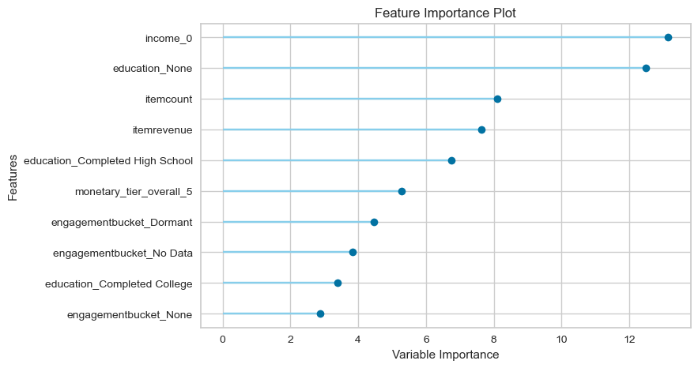

```python
plot_model(smote_model_matrix, plot="feature")
```

# Train with only name_gender_predict (Python Gender Package)

```python
setup(
    data=df_temp,
    target='gender',
    train_size=0.85,
    data_split_shuffle=True,
    silent=True,
    verbose=False,
    ignore_features=['dimcustomermasterid', 'lkupclientid', 'namefirst', 'income',
       'education', 'occupation', 'monetary_tier_overall', 'engagementbucket',
       'loyaltypointbalance', 'isgamer', 'itemdescription', 'itemcount',
       'itemrevenue', 'purchasecount', 'totalspent']
)
```

[output not shown]

[output cut: 533 more lines]

[output not shown]

```python
smote_model_matrix = compare_models(
    fold=2,
    include= ["lightgbm", "catboost", "rf", "svm", "xgboost", "dummy", "lr"]
)
```

|  | Model | Accuracy | AUC | Recall | Prec. | F1 | Kappa | MCC | TT (Sec) |
| --- | --- | --- | --- | --- | --- | --- | --- | --- | --- |
| lightgbm | Light Gradient Boosting Machine | 0.9017 | 0.9230 | 0.6456 | 0.8385 | 0.8690 | 0.8037 | 0.8115 | 28.5000 |
| catboost | CatBoost Classifier | 0.9017 | 0.9230 | 0.6456 | 0.8385 | 0.8690 | 0.8037 | 0.8115 | 101.6500 |
| rf | Random Forest Classifier | 0.9017 | 0.9230 | 0.6456 | 0.8385 | 0.8690 | 0.8037 | 0.8115 | 14.0850 |
| xgboost | Extreme Gradient Boosting | 0.9017 | 0.9230 | 0.6456 | 0.8385 | 0.8690 | 0.8037 | 0.8115 | 76.7750 |
| lr | Logistic Regression | 0.9017 | 0.9230 | 0.6456 | 0.8385 | 0.8690 | 0.8037 | 0.8115 | 8.6700 |
| svm | SVM - Linear Kernel | 0.9008 | 0.0000 | 0.6457 | 0.8380 | 0.8682 | 0.8024 | 0.8100 | 5.5100 |
| dummy | Dummy Classifier | 0.5944 | 0.5000 | 0.3333 | 0.3533 | 0.4432 | 0.0000 | 0.0000 | 3.6300 |

The above result shows the results of only using the python package to get the probability of a gender, while the table below shows the full model with the features selected for this experiment.

Comparing these two shows that the added features marginally increases the accuracy.

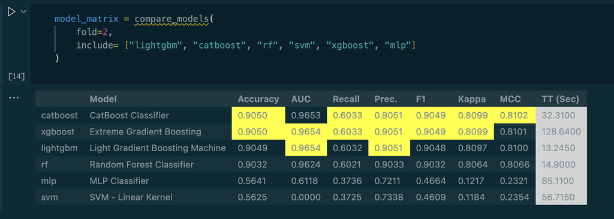

```python
final_model = finalize_model(smote_model_matrix)
```

```python
# List of female first names
first_names_female = ["Emma", "Olivia", "Ava", "Isabella", "Sophia", "Charlotte", "Mia", "Amelia", "Harper", "Evelyn", "Abigail", "Emily", "Elizabeth", "Mila", "Ella", "Avery", "Sofia", "Camila", "Aria", "Scarlett", "Victoria", "Madison", "Luna", "Grace", "Chloe", "Penelope", "Layla", "Riley", "Zoey", "Nora", "Lily", "Eleanor", "Hannah", "Lillian", "Addison", "Aubrey", "Ellie", "Stella", "Natalie", "Zoe", "Leah", "Hazel", "Violet", "Aurora", "Savannah", "Audrey", "Brooklyn", "Bella", "Claire", "Skylar", "Lucy", "Paisley", "Everly", "Anna", "Caroline", "Nova", "Genesis", "Emilia", "Kennedy", "Samantha", "Maya", "Willow", "Kinsley", "Naomi", "Aaliyah", "Elena", "Ariana", "Sarah", "Allison", "Gabriella", "Alice", "Madelyn", "Cora", "Ruby", "Eva", "Serenity", "Autumn", "Adeline", "Hailey", "Gianna", "Valentina", "Isla", "Eliana", "Quinn", "Nevaeh", "Ivy", "Sadie", "Piper", "Lydia", "Alexa", "Josephine", "Emery", "Julia", "Delilah", "Arianna", "Vivian", "Kaylee"]

# List of male first names
first_names_male = ["Liam", "Noah", "Oliver", "Elijah", "William", "James", "Benjamin", "Lucas", "Henry", "Alexander", "Mason", "Michael", "Ethan", "Daniel", "Jacob", "Logan", "Jackson", "Levi", "Sebastian", "Mateo", "Jack", "Owen", "Theodore", "Aiden", "Samuel", "Matthew", "Leo", "David", "Joseph", "Caleb", "Isaac", "Wyatt", "John", "Lincoln", "Ezra", "Grayson", "Luke", "Cameron", "Connor", "Eli", "Nathan", "Nicholas", "Julian", "Aaron", "Adam", "Robert", "Zachary", "Thomas", "Nolan", "Ian", "Evan", "Cooper", "Miles", "Carson", "Gabriel", "Anthony", "Harrison", "Dominic", "Hunter", "David", "Cole", "Colton", "Oscar", "Leo", "Bryson", "Vincent", "Kai", "Caden", "Jayden", "Maxwell", "Silas", "Weston", "Micah", "Declan", "Jaxson", "Ryder", "August", "River", "Emmett", "Brandon", "Beau", "Brayden", "George", "Asher"]
```

## Testing for female names

```python
female_df = pd.DataFrame(first_names_female, columns=['namefirst'])
```

```python
female_df.shape
```

```
(97, 1)
```

```python
female_df["name_gender_predict"] = female_df["namefirst"].apply(gdectect.get_gender)
```

```python
name_results = predict_model(final_model, female_df)
```

```python
name_results.groupby("Label").count()
```

| Label | namefirst | name_gender_predict | Score |
| --- | --- | --- | --- |
| female | 86 | 86 | 86 |
| male | 11 | 11 | 11 |

```python
name_results[name_results["Label"] == "male"]
```

|  | namefirst | name_gender_predict | Label | Score |
| --- | --- | --- | --- | --- |
| 8 | Harper | male | male | 0.9307 |
| 15 | Avery | andy | male | 0.4429 |
| 27 | Riley | mostly_male | male | 0.8103 |
| 34 | Addison | andy | male | 0.4429 |
| 35 | Aubrey | andy | male | 0.4429 |
| 49 | Skylar | andy | male | 0.4429 |
| 51 | Paisley | unknown | male | 0.4429 |
| 52 | Everly | unknown | male | 0.4429 |
| 62 | Kinsley | unknown | male | 0.4429 |
| 83 | Quinn | mostly_male | male | 0.8103 |
| 91 | Emery | male | male | 0.9307 |

## Now testing for male names

```python
male_df = pd.DataFrame(first_names_male, columns=['namefirst'])
male_df.shape
```

```
(84, 1)
```

```python
male_df["name_gender_predict"] = male_df["namefirst"].apply(gdectect.get_gender)
```

```python
name_results = predict_model(final_model, male_df)
```

```python
name_results.groupby("Label").count()
```

| Label | namefirst | name_gender_predict | Score |
| --- | --- | --- | --- |
| female | 1 | 1 | 1 |
| male | 83 | 83 | 83 |

```python
name_results[name_results["Label"] == "female"]
```

|  | namefirst | name_gender_predict | Label | Score |
| --- | --- | --- | --- | --- |
| 39 | Eli | female | female | 0.9196 |